# Report

Michal Odler

1.3.2022

## Exploratory analysis

### Neuronal parameters:

Histograms and boxplots - Original data.

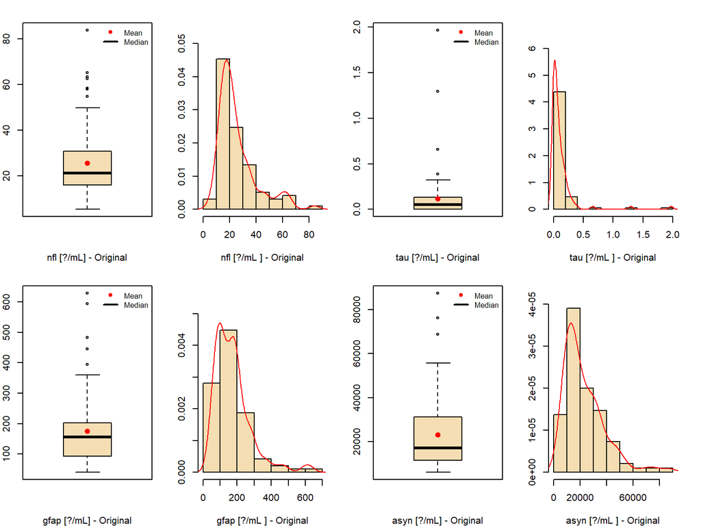

### Pesticides:

Histograms and boxplots - Originial data.

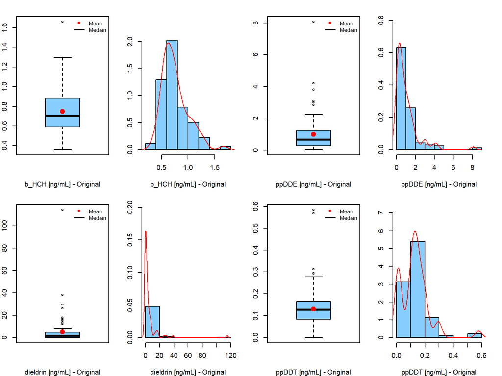

### Scatter plots:

Neuronal parameters by $\beta$-HCH:

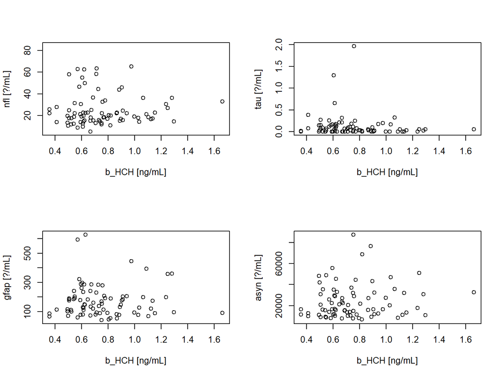

Neuronal parameters by DDE:

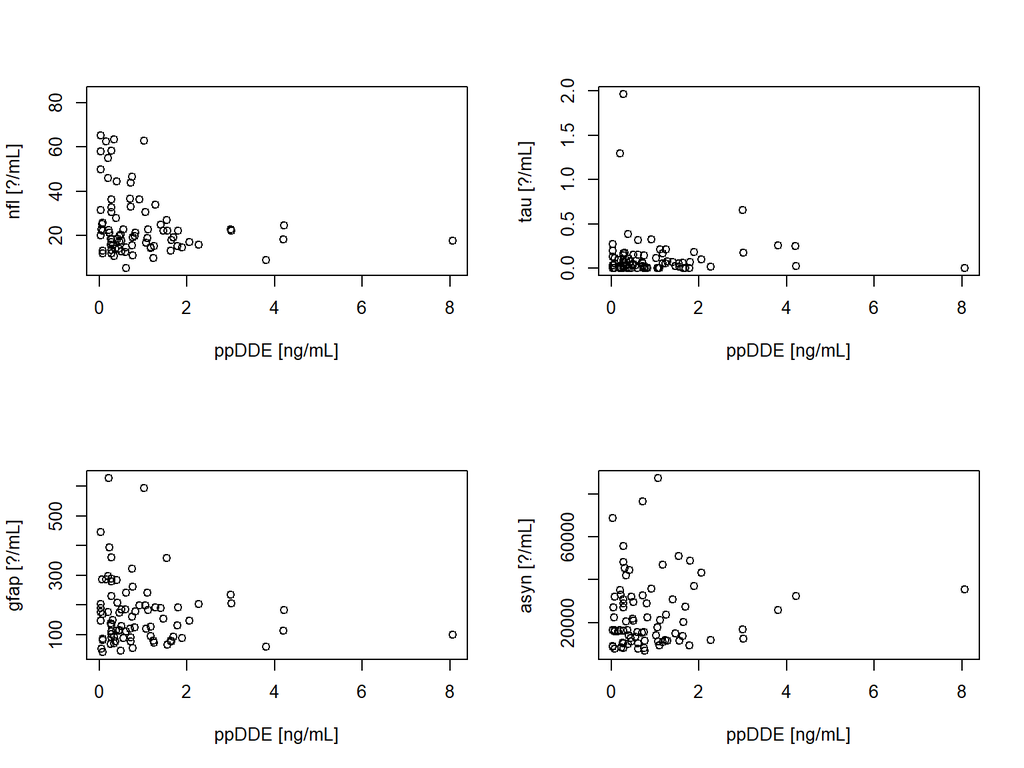

Neuronal parameters by dieldrin:

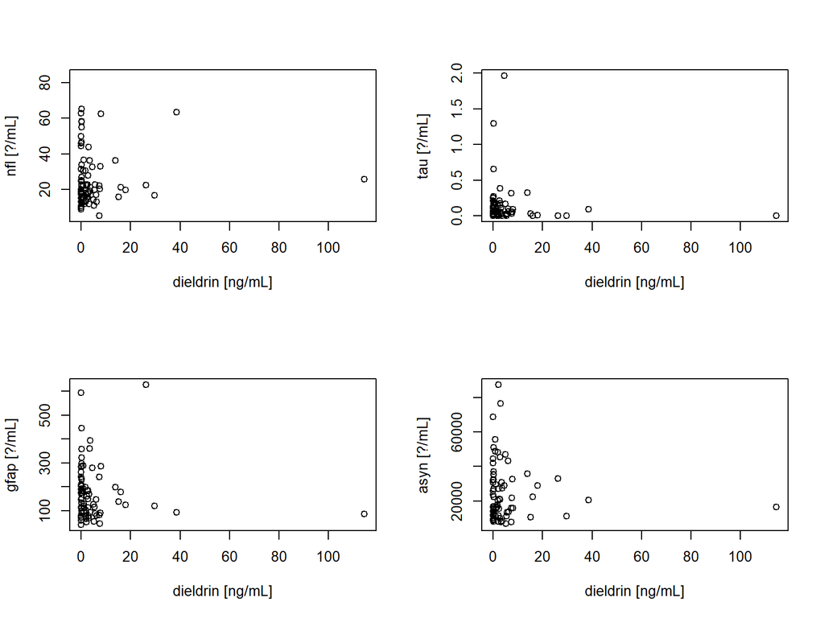

Neuronal parameters by DDT:

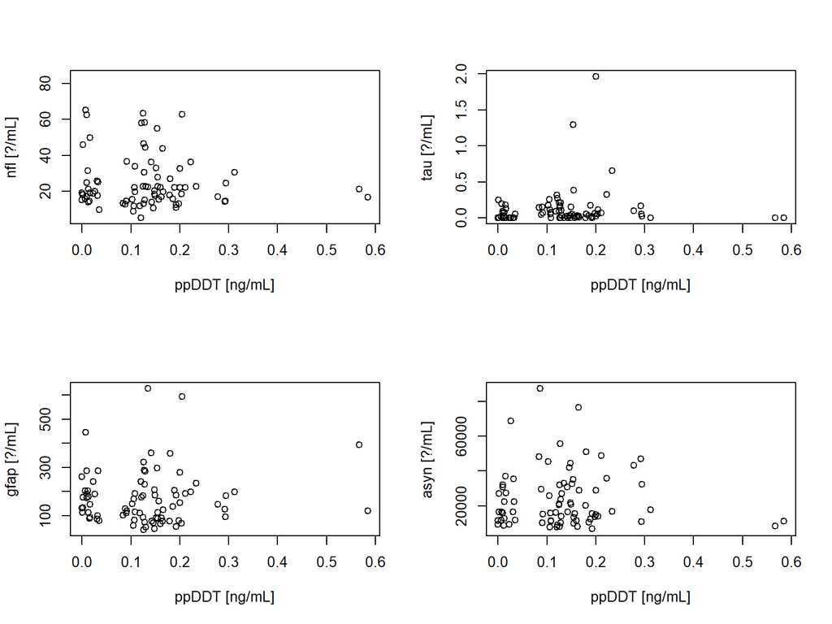

## Winsorization

The presence of outliers in our variables may have strong undesirable effect on sample Pearson correlation coefficients, hence we apply one-sided winsorization to our data (values larger than $x_{0.75} + 1.5 \cdot IQR(x)$ will be replaced by this value). Histograms and boxplots of the augmented variables can be seen below.

### Neuronal parameters:

Histograms and boxplots - Winsorized data.

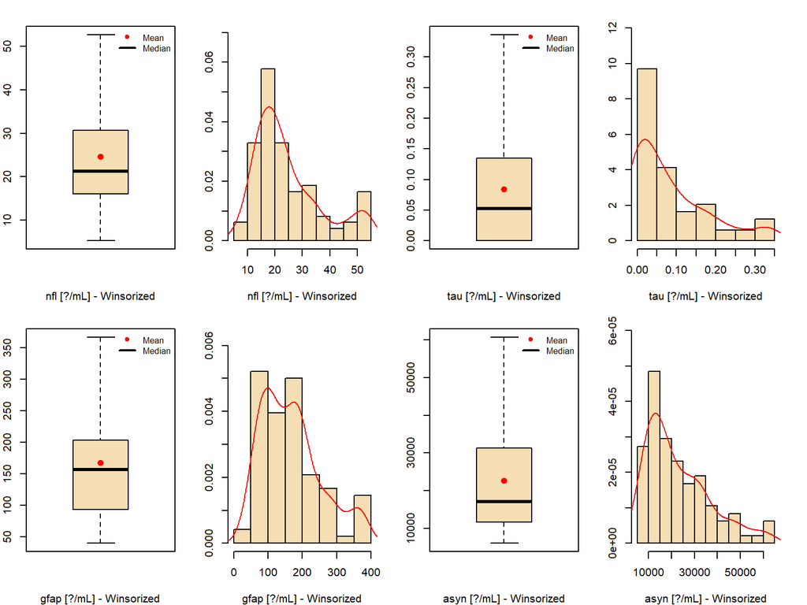

### Pesticides:

Histograms and boxplots - Winsorized data.

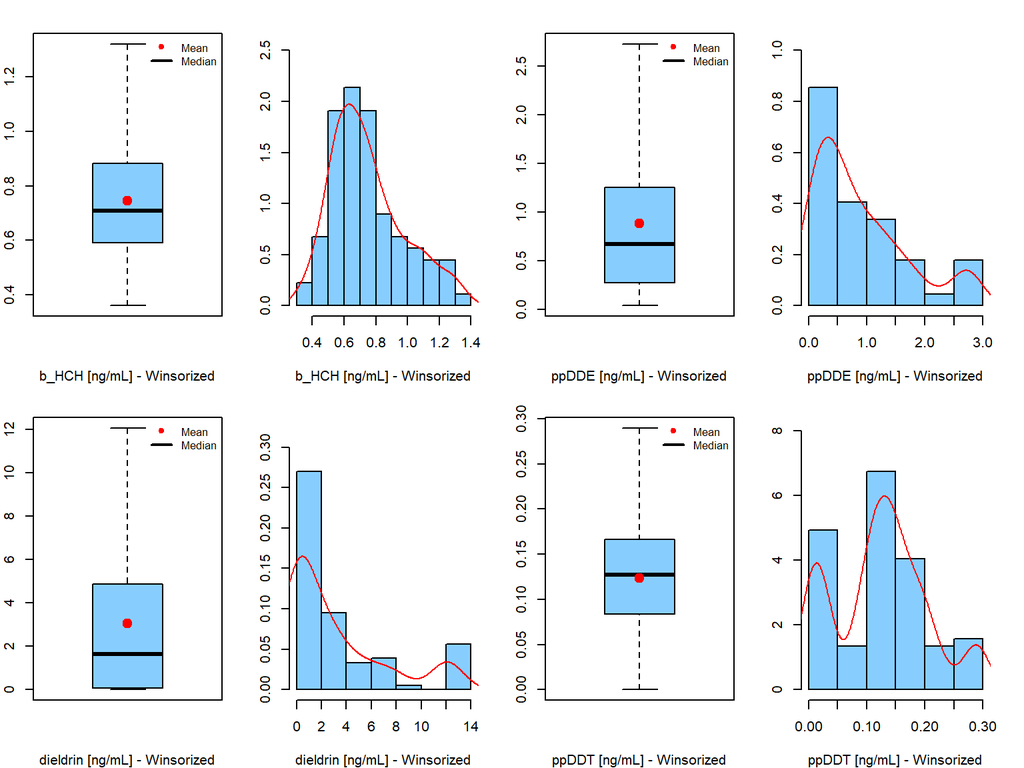

### Scatter plots - Winsorized:

Neuronal parameters by $\beta$-HCH:

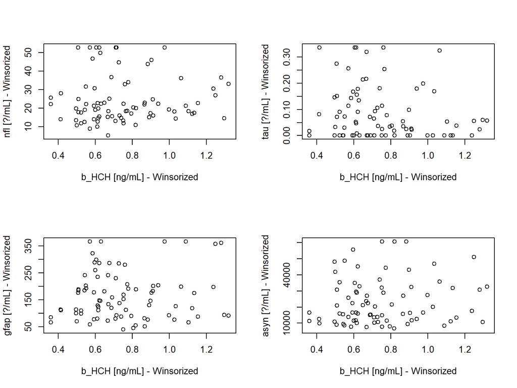

Neuronal parameters by DDE:

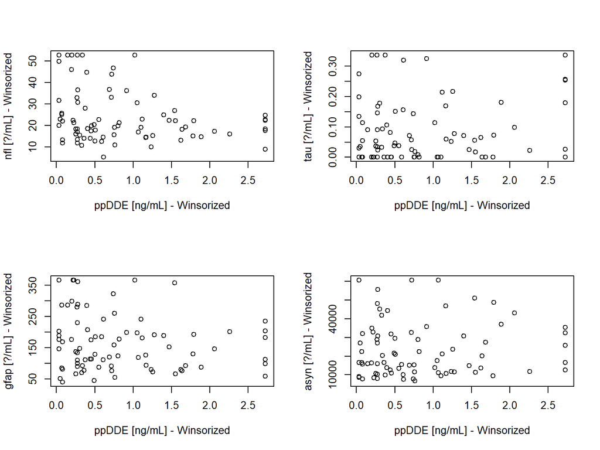

Neuronal parameters by dieldrin:

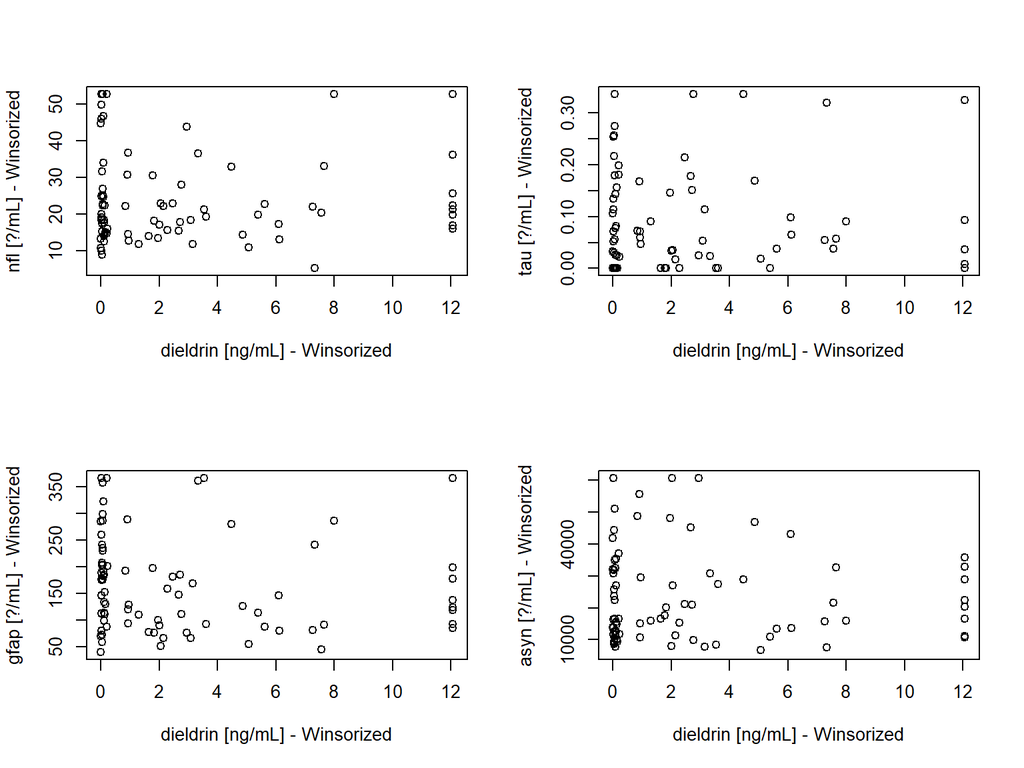

Neuronal parameters by DDT:

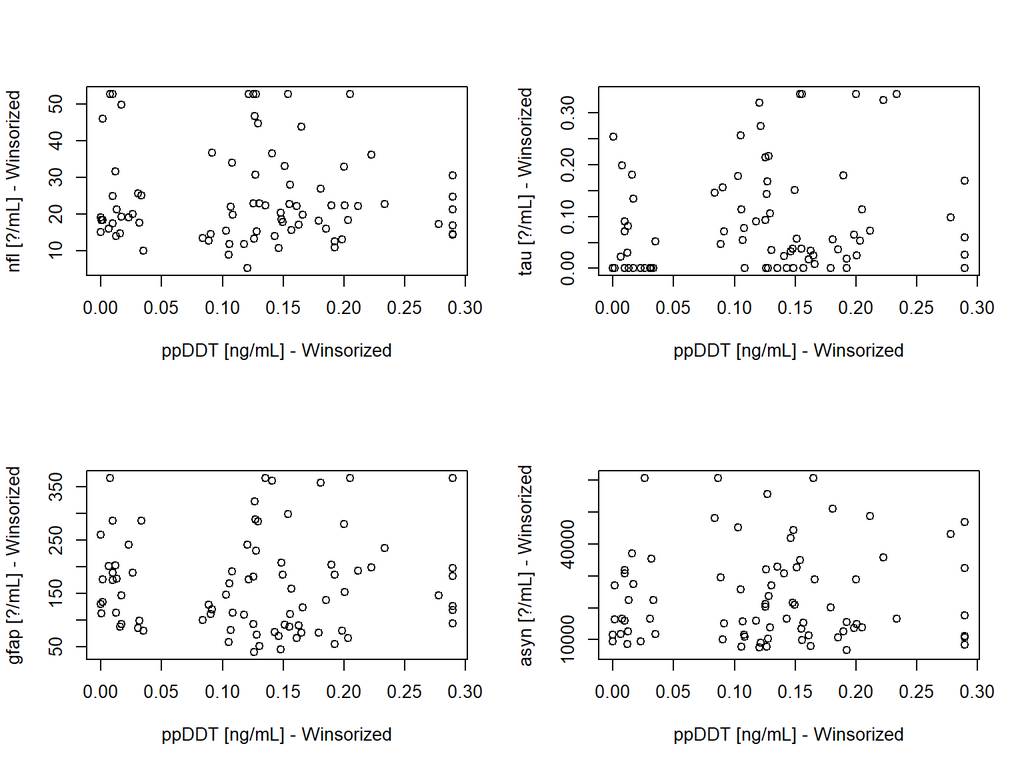

## Hypotheses testing

### Pearson correlation coefficient

The following table contains results of one sample $t$-tests about the Pearson correlation coefficient $\rho_{XY}$ of given pesticide-biomarker pairs computed on the original data (*(orig.)*) and winsorized data (*(wins.)*). The null hypotheses states no linear association between variables ($H_0: \rho_{XY} = 0$) against the two sided alternative, that such an association exists ($H_1: \rho_{XY} \neq 0$). The 95 % confidence intervals and $p$-values are included.

Since outliers may affect the sample Pearson correlation and give misleading results we consider the tests conducted on winsorized data as more trustworhy.

One sample Pearson correlation $t$-tests: Original and winsorized data

|  | rho (orig.) | lwr. 95%CI (orig.) | upp. 95%CI (orig.) | p-value (orig.) | Sidak-corrected significance (orig.) | rho (wins.) | lwr. 95%CI (wins.) | upp. 95%CI (wins.) | p-value (wins.) | Sidak-corrected significance (wins.) |
| --- | --- | --- | --- | --- | --- | --- | --- | --- | --- | --- |
| nfl-b_HCH | 0.0344 | -0.1854 | 0.2508 | 0.7606 | FALSE | 0.0401 | -0.1798 | 0.2562 | 0.7222 | FALSE |
| nfl-ppDDE | -0.2224 | -0.4204 | -0.0043 | 0.0459 | FALSE | -0.2725 | -0.4633 | -0.0576 | 0.0138 | FALSE |
| nfl-dieldrin | 0.0531 | -0.1672 | 0.2684 | 0.6376 | FALSE | -0.0117 | -0.2295 | 0.2071 | 0.9171 | FALSE |
| nfl-ppDDT | -0.0839 | -0.2968 | 0.1369 | 0.4564 | FALSE | -0.0614 | -0.2761 | 0.1591 | 0.5861 | FALSE |
| tau-b_HCH | -0.1007 | -0.3122 | 0.1203 | 0.3709 | FALSE | -0.1745 | -0.3784 | 0.0456 | 0.1192 | FALSE |
| tau-ppDDE | -0.0183 | -0.2357 | 0.2009 | 0.8714 | FALSE | 0.1268 | -0.0941 | 0.3359 | 0.2592 | FALSE |
| tau-dieldrin | -0.0683 | -0.2825 | 0.1523 | 0.5445 | FALSE | -0.0593 | -0.2741 | 0.1611 | 0.5989 | FALSE |
| tau-ppDDT | 0.0813 | -0.1395 | 0.2945 | 0.4704 | FALSE | 0.1103 | -0.1107 | 0.3209 | 0.3269 | FALSE |
| gfap-b_HCH | 0.0245 | -0.1949 | 0.2416 | 0.8281 | FALSE | 0.0777 | -0.1431 | 0.2911 | 0.4907 | FALSE |
| gfap-ppDDE | -0.1368 | -0.3448 | 0.0841 | 0.2233 | FALSE | -0.1306 | -0.3393 | 0.0903 | 0.2452 | FALSE |
| gfap-dieldrin | -0.0572 | -0.2722 | 0.1632 | 0.6119 | FALSE | -0.1087 | -0.3194 | 0.1124 | 0.3342 | FALSE |
| gfap-ppDDT | 0.0753 | -0.1454 | 0.2889 | 0.5038 | FALSE | 0.0159 | -0.2031 | 0.2334 | 0.8879 | FALSE |
| asyn-b_HCH | 0.1138 | -0.1101 | 0.3267 | 0.3180 | FALSE | 0.1149 | -0.1090 | 0.3277 | 0.3134 | FALSE |
| asyn-ppDDE | 0.0765 | -0.1471 | 0.2926 | 0.5029 | FALSE | 0.0550 | -0.1682 | 0.2728 | 0.6303 | FALSE |
| asyn-dieldrin | -0.0641 | -0.2812 | 0.1593 | 0.5745 | FALSE | -0.0393 | -0.2581 | 0.1834 | 0.7311 | FALSE |
| asyn-ppDDT | -0.0392 | -0.2580 | 0.1835 | 0.7318 | FALSE | 0.0441 | -0.1787 | 0.2627 | 0.6993 | FALSE |

### Spearman correlation coefficient

The following table contains results of one sample $t$-tests about the Spearman correlation coefficient, which is a non-parametric measure of correlation between variables based on ranks and asseses monotonic relationship between variables, not just a linear relationship. The stated hypotheses were analogous to the previous case, but Spearman correlation is robust to outliers and violations of normality. 95 % confidence intervals based on Z-transformation and $p$-values are included.

One sample Spearman correlation $t$-tests

|  | rho (spear.) | lwr. 95%CI (spear.) | upp. 95%CI (spear.) | p-value (spear.) | Sidak-corrected significance (spear.) |
| --- | --- | --- | --- | --- | --- |
| nfl-b_HCH | 0.1017 | -0.1193 | 0.3131 | 0.3813 | FALSE |
| nfl-ppDDE | -0.2511 | -0.4451 | -0.0347 | 0.0277 | FALSE |
| nfl-dieldrin | -0.0181 | -0.2355 | 0.2011 | 0.8767 | FALSE |
| nfl-ppDDT | 0.0165 | -0.2026 | 0.2340 | 0.8877 | FALSE |
| tau-b_HCH | -0.1377 | -0.3456 | 0.0832 | 0.2347 | FALSE |
| tau-ppDDE | 0.0704 | -0.1503 | 0.2844 | 0.5454 | FALSE |
| tau-dieldrin | -0.0201 | -0.2374 | 0.1992 | 0.8633 | FALSE |
| tau-ppDDT | 0.0949 | -0.1261 | 0.3069 | 0.4143 | FALSE |
| gfap-b_HCH | 0.0102 | -0.2086 | 0.2280 | 0.9305 | FALSE |
| gfap-ppDDE | -0.1200 | -0.3298 | 0.1010 | 0.3008 | FALSE |
| gfap-dieldrin | -0.1871 | -0.3896 | 0.0326 | 0.1043 | FALSE |
| gfap-ppDDT | -0.0230 | -0.2401 | 0.1964 | 0.8437 | FALSE |
| asyn-b_HCH | 0.1066 | -0.1173 | 0.3202 | 0.3648 | FALSE |
| asyn-ppDDE | 0.0701 | -0.1533 | 0.2868 | 0.5519 | FALSE |
| asyn-dieldrin | -0.0172 | -0.2374 | 0.2047 | 0.8840 | FALSE |
| asyn-ppDDT | 0.0284 | -0.1939 | 0.2479 | 0.8100 | FALSE |